# Pertemuan 1-Pengantar Algoritma dan Pemrograman

Author

Fitri Diana Musa

Published

September 22, 2026

## Rangkuman Materi

### Algoritma

Algoritma adalah serangkaian langkah yang disusun secara sistematis, logis, dan jelas untuk menyelesaikan suatu masalah dan mencapai tujuan tertentu.

**Algoritma** merupakan rencana atau langkah penyelesaian masalah, sedangkan **pemrograman** merupakan proses menerjemahkan algoritma ke dalam bahasa pemrograman agar dapat dijalankan oleh komputer.

Hubungannya:

Masalah → Algoritma → Bahasa Pemrograman → Program → Hasil

Dengan kata lain:

**Algoritma** menjelaskan apa dan bagaimana masalah diselesaikan, sedangkan **pemrograman** menerjemahkan langkah tersebut menjadi instruksi yang dapat dipahami komputer.

Kesimpulannya algoritma merupakan:

- Langkah-langkah yang dilakukan agar solusi masalah dapat diperoleh.
- Suatu prosedur yang merupakan urutan langkah-langkah yg berintegrasi.
- Suatu metode khusus yang digunakan untuk menyelesaikan suatu masalah yang nyata.

Bentuk atau metode penulisan (notasi) algoritma secara umum ada dua, yaitu:

1. Pseudocode : Menuliskan algoritma memakai kode semu yang mirip dengan struktur bahasa pemrograman asli tetapi tidak punya aturan sintaksis yang baku.
2. Flowchart : Menggambarkan urutan langkah logis program secara visual memakai simbol-simbol bangun datar tertentu.

### Flowchart

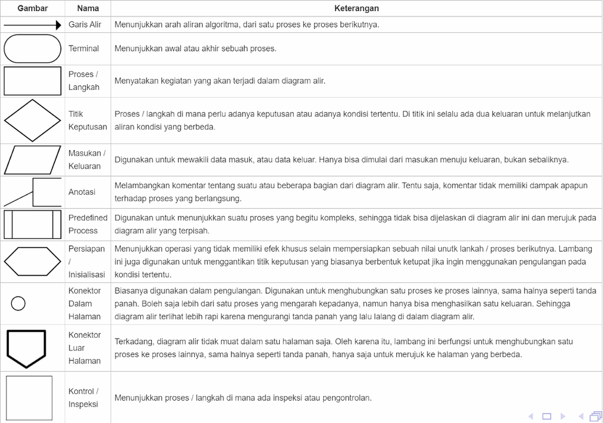

Simbol standar flowchart dan keterangannya.

Flowchart dapat dibuat secara manual atau menggunakan perangkat bantu seperti diagrams.net (draw.io), Lucidchart, Canva, Microsoft Visio, maupun PowerPoint.

### Struktur Algoritma

1. **Runtunan (*Sequence*)** : Runtunan adalah struktur algoritma yang menjalankan instruksi **secara berurutan**, dari langkah pertama hingga langkah terakhir. Pada struktur ini:
   - tidak ada pemilihan kondisi;
   - tidak ada pengulangan;
   - setiap instruksi dijalankan satu kali;
   - urutan instruksi sangat penting.

   Bentuk umum Runtunan :

   Mulai

   ↓

   Langkah 1

   ↓

   Langkah 2

   ↓

   Langkah 3

   ↓

   Selesai

   Contoh : Menghitung Luas Lingkaran

   Masalah : Diketahui jari-jari sebuah lingkaran sebesar `r`. Tentukan luas lingkaran tersebut.

   Penyelesaiannya dapat dituliskan dengan algoritma berikut:
   - Mulai.
   - Masukkan nilai jari-jari `r`.
   - Hitung luas lingkaran.
   - Tampilkan hasil luas.
   - Selesai.
2. **Pemilihan atau Percabangan (*Selection*)** : Struktur algoritma yang digunakan untuk menentukan instruksi yang akan dijalankan berdasarkan kondisi tertentu. Dengan kata lain, tidak semua instruksi akan selalu dijalankan. Program akan melakukan:
   - tindakan A jika kondisi tertentu terpenuhi;
   - tindakan B jika kondisi tidak terpenuhi.

Bentuk-bentuk Struktur Percabangan :

- **if** : Digunakan jika suatu tindakan hanya dilakukan ketika kondisi bernilai **benar**.

Contoh :

Jika nilai mahasiswa lebih besar atau sama dengan 60, tampilkan **Lulus**.

Input nilai

Jika nilai ≥ 60 Tampilkan “Lulus”

Jika nilai = 50, program tidak melakukan tindakan apa pun.

- if-else : Digunakan ketika terdapat dua kemungkinan tindakan.

  Contoh :

  Input nilai

  Jika nilai ≥ 60

  Tampilkan “Lulus”

  Jika tidak

  Tampilkan “Tidak Lulus”
- **case** : Struktur case atau pemilihan multi-kondisi digunakan ketika terdapat banyak pilihan berdasarkan suatu nilai. Dengan kata lain, jika kondisi tertentu terpenuhi, pilih tindakan yang sesuai. Kemudian saat masuk ke implementasi bahasa pemrograman: struktur percabangan multi-kondisi ini dapat diimplementasikan dengan switch.

  Perbandingan switch dan case :

| Istilah | Fungsi |
| --- | --- |
| **`switch`** | Struktur untuk memilih di antara banyak kemungkinan |
| **`case`** | Setiap pilihan/nilai dalam struktur `switch` |

3. **Perulangan (*Loop/Iteration*)** : digunakan ketika suatu instruksi perlu dijalankan **lebih dari satu kali**. Dalam struktur perulangan, ada 3 bentuk atau jenis struktur perulangan, yaitu : for, while dan repeat. Ketiga struktur ini digunakan untuk menjalankan instruksi secara berulang, tetapi **berbeda pada cara menentukan kapan perulangan berhenti**.
- **for** : Digunakan ketika **jumlah perulangan atau urutan data yang akan diproses sudah diketahui**.
- **while** : Digunakan ketika instruksi perlu terus dijalankan **selama suatu kondisi masih terpenuhi**.
- **repeat** : Pada repeat, instruksi dijalankan terlebih dahulu, kemudian proses dihentikan dengan kondisi tertentu. **Ciri utama:** perulangan akan terus berjalan sampai dihentikan secara eksplisit menggunakan break.

  Perbandingan for, while dan repeat :

  | Struktur | Digunakan ketika | Kondisi berhenti |
  | --- | --- | --- |
  | `for` | Jumlah iterasi diketahui | Batas iterasi tercapai |
  | `while` | Bergantung pada kondisi | Kondisi menjadi salah |
  | `repeat` | Proses terus dilakukan | Dihentikan secara eksplisit |

## Latihan Soal

1. Buatlah algoritma dan flowchart untuk menghitung simpangan baku dari 3 data.
2. Apa kegunaan dari algoritma berikut

   `Input: Bilangan bulat positif n`

   `Output: Nilai f`
   1. `f ← 0`
   2. `Untuk i dari 1 sampai n lakukan f ← f + (n mod i)`
   3. `Kembalikan f`